# VideoGamesSales_Project

[figure not shown]

## **Ejercicio Practico Video Games Sales**

```
    Poniendo en practica lo aprendido en el curso se FreeCodeCamp "Data Analysis with Python"
```

[figure not shown]

**Dia 1 Orientación e Inspección (El Mapa del Tesoro)**

Tema del Día: Inspección de DataFrames. Repaso profundo de .info(), .describe(), .shape, .columns, .dtypes. Entender qué te dice cada uno sobre la "salud" de tus datos.

Aplicación al Proyecto: Carga el CSV de videojuegos y ejecuta todas las funciones de inspección. En una celda de Markdown, anota tus hallazgos iniciales: ¿Cuántas filas/columnas hay? ¿Qué tipos de datos ves? ¿Hay valores nulos a simple vista?

```python
import pandas as pd
import numpy as np
import seaborn as sns
import matplotlib.pyplot as plt

print(pd.__version__)
print(np.__version__)
print(sns.__version__)
```

```
2.3.1
2.3.2
0.13.2
```

```python
df_videogames = pd.read_csv('vgsales.csv')

df_videogames.head()
```

|  | Rank | Name | Platform | Year | Genre | Publisher | NA_Sales | EU_Sales | JP_Sales | Other_Sales | Global_Sales |
| --- | --- | --- | --- | --- | --- | --- | --- | --- | --- | --- | --- |
| 0 | 1 | Wii Sports | Wii | 2006.0 | Sports | Nintendo | 41.49 | 29.02 | 3.77 | 8.46 | 82.74 |
| 1 | 2 | Super Mario Bros. | NES | 1985.0 | Platform | Nintendo | 29.08 | 3.58 | 6.81 | 0.77 | 40.24 |
| 2 | 3 | Mario Kart Wii | Wii | 2008.0 | Racing | Nintendo | 15.85 | 12.88 | 3.79 | 3.31 | 35.82 |
| 3 | 4 | Wii Sports Resort | Wii | 2009.0 | Sports | Nintendo | 15.75 | 11.01 | 3.28 | 2.96 | 33.00 |
| 4 | 5 | Pokemon Red/Pokemon Blue | GB | 1996.0 | Role-Playing | Nintendo | 11.27 | 8.89 | 10.22 | 1.00 | 31.37 |

```python
df_videogames.info()
```

```
<class 'pandas.core.frame.DataFrame'>
RangeIndex: 16598 entries, 0 to 16597
Data columns (total 11 columns):
 #   Column        Non-Null Count  Dtype
---  ------        --------------  -----
 0   Rank          16598 non-null  int64
 1   Name          16598 non-null  object
 2   Platform      16598 non-null  object
 3   Year          16327 non-null  float64
 4   Genre         16598 non-null  object
 5   Publisher     16540 non-null  object
 6   NA_Sales      16598 non-null  float64
 7   EU_Sales      16598 non-null  float64
 8   JP_Sales      16598 non-null  float64
 9   Other_Sales   16598 non-null  float64
 10  Global_Sales  16598 non-null  float64
dtypes: float64(6), int64(1), object(4)
memory usage: 1.4+ MB
```

[figure not shown]

### Hallazgos de inspección .info()

- Me dice que para la celdas Year, cuenta con datos NaN, por lo que necesitare una estrategia para limpiarlos y quiza por eso Panda lo toma como un dato float64 cuando deberia ser int64.
- Me dice que para la celdas Publisher, cuenta con datos NaN, por lo que necesitare una estrategia para limpiarlos

```python
df_videogames.describe()
```

|  | Rank | Year | NA_Sales | EU_Sales | JP_Sales | Other_Sales | Global_Sales |
| --- | --- | --- | --- | --- | --- | --- | --- |
| count | 16598.000000 | 16327.000000 | 16598.000000 | 16598.000000 | 16598.000000 | 16598.000000 | 16598.000000 |
| mean | 8300.605254 | 2006.406443 | 0.264667 | 0.146652 | 0.077782 | 0.048063 | 0.537441 |
| std | 4791.853933 | 5.828981 | 0.816683 | 0.505351 | 0.309291 | 0.188588 | 1.555028 |
| min | 1.000000 | 1980.000000 | 0.000000 | 0.000000 | 0.000000 | 0.000000 | 0.010000 |
| 25% | 4151.250000 | 2003.000000 | 0.000000 | 0.000000 | 0.000000 | 0.000000 | 0.060000 |
| 50% | 8300.500000 | 2007.000000 | 0.080000 | 0.020000 | 0.000000 | 0.010000 | 0.170000 |
| 75% | 12449.750000 | 2010.000000 | 0.240000 | 0.110000 | 0.040000 | 0.040000 | 0.470000 |
| max | 16600.000000 | 2020.000000 | 41.490000 | 29.020000 | 10.220000 | 10.570000 | 82.740000 |

[figure not shown]

### Hallazgos de inspección .describe()

- Me dice que para la celda Global_Sales, cuenta con una desviasion estandar de 1.555028 se presume alta, lo que sugiere presencia de outliers (juegos con ventas masivas que podrian sesgar el promedio)

```python
df_videogames.shape
```

```
(16598, 11)
```

```python
df_videogames.columns
```

```
Index(['Rank', 'Name', 'Platform', 'Year', 'Genre', 'Publisher', 'NA_Sales',
       'EU_Sales', 'JP_Sales', 'Other_Sales', 'Global_Sales'],
      dtype='object')
```

```python
df_videogames.dtypes
```

```
Rank              int64
Name             object
Platform         object
Year            float64
Genre            object
Publisher        object
NA_Sales        float64
EU_Sales        float64
JP_Sales        float64
Other_Sales     float64
Global_Sales    float64
dtype: object
```

[figure not shown]

#### Practica del dia 2

```python
df_videogames['Name'].loc[5:11]
```

```
5                        Tetris
6         New Super Mario Bros.
7                      Wii Play
8     New Super Mario Bros. Wii
9                     Duck Hunt
10                   Nintendogs
11                Mario Kart DS
Name: Name, dtype: object
```

```python
df_videogames[['Name','Platform','Global_Sales']].loc[5:10]
```

|  | Name | Platform | Global_Sales |
| --- | --- | --- | --- |
| 5 | Tetris | GB | 30.26 |
| 6 | New Super Mario Bros. | DS | 30.01 |
| 7 | Wii Play | Wii | 29.02 |
| 8 | New Super Mario Bros. Wii | Wii | 28.62 |
| 9 | Duck Hunt | NES | 28.31 |
| 10 | Nintendogs | DS | 24.76 |

```python
df_videogames.iloc[0]
```

```
Rank                     1
Name            Wii Sports
Platform               Wii
Year                2006.0
Genre               Sports
Publisher         Nintendo
NA_Sales             41.49
EU_Sales             29.02
JP_Sales              3.77
Other_Sales           8.46
Global_Sales         82.74
Name: 0, dtype: object
```

```python
df_videogames.tail()
```

|  | Rank | Name | Platform | Year | Genre | Publisher | NA_Sales | EU_Sales | JP_Sales | Other_Sales | Global_Sales |
| --- | --- | --- | --- | --- | --- | --- | --- | --- | --- | --- | --- |
| 16593 | 16596 | Woody Woodpecker in Crazy Castle 5 | GBA | 2002.0 | Platform | Kemco | 0.01 | 0.00 | 0.0 | 0.0 | 0.01 |
| 16594 | 16597 | Men in Black II: Alien Escape | GC | 2003.0 | Shooter | Infogrames | 0.01 | 0.00 | 0.0 | 0.0 | 0.01 |
| 16595 | 16598 | SCORE International Baja 1000: The Official Game | PS2 | 2008.0 | Racing | Activision | 0.00 | 0.00 | 0.0 | 0.0 | 0.01 |
| 16596 | 16599 | Know How 2 | DS | 2010.0 | Puzzle | 7G//AMES | 0.00 | 0.01 | 0.0 | 0.0 | 0.01 |
| 16597 | 16600 | Spirits & Spells | GBA | 2003.0 | Platform | Wanadoo | 0.01 | 0.00 | 0.0 | 0.0 | 0.01 |

```python
df_videogames[['Name','Platform','Year']].iloc[16593:16598]
```

|  | Name | Platform | Year |
| --- | --- | --- | --- |
| 16593 | Woody Woodpecker in Crazy Castle 5 | GBA | 2002.0 |
| 16594 | Men in Black II: Alien Escape | GC | 2003.0 |
| 16595 | SCORE International Baja 1000: The Official Game | PS2 | 2008.0 |
| 16596 | Know How 2 | DS | 2010.0 |
| 16597 | Spirits & Spells | GBA | 2003.0 |

```python
df_videogames.loc[df_videogames['Genre'] == 'Sports']
```

|  | Rank | Name | Platform | Year | Genre | Publisher | NA_Sales | EU_Sales | JP_Sales | Other_Sales | Global_Sales |
| --- | --- | --- | --- | --- | --- | --- | --- | --- | --- | --- | --- |
| 0 | 1 | Wii Sports | Wii | 2006.0 | Sports | Nintendo | 41.49 | 29.02 | 3.77 | 8.46 | 82.74 |
| 3 | 4 | Wii Sports Resort | Wii | 2009.0 | Sports | Nintendo | 15.75 | 11.01 | 3.28 | 2.96 | 33.00 |
| 13 | 14 | Wii Fit | Wii | 2007.0 | Sports | Nintendo | 8.94 | 8.03 | 3.60 | 2.15 | 22.72 |
| 14 | 15 | Wii Fit Plus | Wii | 2009.0 | Sports | Nintendo | 9.09 | 8.59 | 2.53 | 1.79 | 22.00 |
| 77 | 78 | FIFA 16 | PS4 | 2015.0 | Sports | Electronic Arts | 1.11 | 6.06 | 0.06 | 1.26 | 8.49 |
| ... | ... | ... | ... | ... | ... | ... | ... | ... | ... | ... | ... |
| 16576 | 16579 | Rugby Challenge 3 | XOne | 2016.0 | Sports | Alternative Software | 0.00 | 0.01 | 0.00 | 0.00 | 0.01 |
| 16578 | 16581 | Outdoors Unleashed: Africa 3D | 3DS | 2011.0 | Sports | Mastiff | 0.01 | 0.00 | 0.00 | 0.00 | 0.01 |
| 16579 | 16582 | PGA European Tour | N64 | 2000.0 | Sports | Infogrames | 0.01 | 0.00 | 0.00 | 0.00 | 0.01 |
| 16581 | 16584 | Fit & Fun | Wii | 2011.0 | Sports | Unknown | 0.00 | 0.01 | 0.00 | 0.00 | 0.01 |
| 16587 | 16590 | Mezase!! Tsuri Master DS | DS | 2009.0 | Sports | Hudson Soft | 0.00 | 0.00 | 0.01 | 0.00 | 0.01 |

2346 rows × 11 columns

[figure not shown]

**Dia 2** - *Aplicacion al proyecto*

Tema del Día: Entender a fondo la diferencia y el poder de .loc[], .iloc[] y el filtrado booleano.

Tarea: En celdas nuevas, escribe el código necesario para resolver los siguientes desafíos:

1. Crea un nuevo DataFrame llamado juegos_recientes que contenga solo los juegos lanzados después del año 2010.
2. Crea un nuevo DataFrame llamado juegos_wii que contenga todos los juegos de la plataforma "Wii".
3. Crea un DataFrame final llamado hits_de_nintendo que cumpla dos condiciones a la vez:
   - Que su Publisher sea "Nintendo". Y que sus ventas en Norteamérica (NA_Sales) sean mayores a 10 millones.

```python
juegos_recientes = df_videogames[df_videogames['Year'] > 2010]

juegos_recientes
```

|  | Rank | Name | Platform | Year | Genre | Publisher | NA_Sales | EU_Sales | JP_Sales | Other_Sales | Global_Sales |
| --- | --- | --- | --- | --- | --- | --- | --- | --- | --- | --- | --- |
| 16 | 17 | Grand Theft Auto V | PS3 | 2013.0 | Action | Take-Two Interactive | 7.01 | 9.27 | 0.97 | 4.14 | 21.40 |
| 23 | 24 | Grand Theft Auto V | X360 | 2013.0 | Action | Take-Two Interactive | 9.63 | 5.31 | 0.06 | 1.38 | 16.38 |
| 29 | 30 | Call of Duty: Modern Warfare 3 | X360 | 2011.0 | Shooter | Activision | 9.03 | 4.28 | 0.13 | 1.32 | 14.76 |
| 32 | 33 | Pokemon X/Pokemon Y | 3DS | 2013.0 | Role-Playing | Nintendo | 5.17 | 4.05 | 4.34 | 0.79 | 14.35 |
| 33 | 34 | Call of Duty: Black Ops 3 | PS4 | 2015.0 | Shooter | Activision | 5.77 | 5.81 | 0.35 | 2.31 | 14.24 |
| ... | ... | ... | ... | ... | ... | ... | ... | ... | ... | ... | ... |
| 16576 | 16579 | Rugby Challenge 3 | XOne | 2016.0 | Sports | Alternative Software | 0.00 | 0.01 | 0.00 | 0.00 | 0.01 |
| 16578 | 16581 | Outdoors Unleashed: Africa 3D | 3DS | 2011.0 | Sports | Mastiff | 0.01 | 0.00 | 0.00 | 0.00 | 0.01 |
| 16581 | 16584 | Fit & Fun | Wii | 2011.0 | Sports | Unknown | 0.00 | 0.01 | 0.00 | 0.00 | 0.01 |
| 16585 | 16588 | Breach | PC | 2011.0 | Shooter | Destineer | 0.01 | 0.00 | 0.00 | 0.00 | 0.01 |
| 16589 | 16592 | Chou Ezaru wa Akai Hana: Koi wa Tsuki ni Shiru... | PSV | 2016.0 | Action | dramatic create | 0.00 | 0.00 | 0.01 | 0.00 | 0.01 |

3886 rows × 11 columns

```python
juegos_wii = df_videogames[df_videogames['Platform'] == 'Wii']

juegos_wii
```

|  | Rank | Name | Platform | Year | Genre | Publisher | NA_Sales | EU_Sales | JP_Sales | Other_Sales | Global_Sales |
| --- | --- | --- | --- | --- | --- | --- | --- | --- | --- | --- | --- |
| 0 | 1 | Wii Sports | Wii | 2006.0 | Sports | Nintendo | 41.49 | 29.02 | 3.77 | 8.46 | 82.74 |
| 2 | 3 | Mario Kart Wii | Wii | 2008.0 | Racing | Nintendo | 15.85 | 12.88 | 3.79 | 3.31 | 35.82 |
| 3 | 4 | Wii Sports Resort | Wii | 2009.0 | Sports | Nintendo | 15.75 | 11.01 | 3.28 | 2.96 | 33.00 |
| 7 | 8 | Wii Play | Wii | 2006.0 | Misc | Nintendo | 14.03 | 9.20 | 2.93 | 2.85 | 29.02 |
| 8 | 9 | New Super Mario Bros. Wii | Wii | 2009.0 | Platform | Nintendo | 14.59 | 7.06 | 4.70 | 2.26 | 28.62 |
| ... | ... | ... | ... | ... | ... | ... | ... | ... | ... | ... | ... |
| 16517 | 16520 | Teenage Mutant Ninja Turtles | Wii | 2007.0 | Action | Konami Digital Entertainment | 0.00 | 0.01 | 0.00 | 0.00 | 0.01 |
| 16552 | 16555 | Mahou Sensei Negima!? Neo-Pactio Fight!! | Wii | 2007.0 | Fighting | Marvelous Interactive | 0.00 | 0.00 | 0.01 | 0.00 | 0.01 |
| 16573 | 16576 | Mini Desktop Racing | Wii | 2007.0 | Racing | Popcorn Arcade | 0.01 | 0.00 | 0.00 | 0.00 | 0.01 |
| 16574 | 16577 | Yattaman Wii: BikkuriDokkiri Machine de Mou Ra... | Wii | 2008.0 | Racing | Takara Tomy | 0.00 | 0.00 | 0.01 | 0.00 | 0.01 |
| 16581 | 16584 | Fit & Fun | Wii | 2011.0 | Sports | Unknown | 0.00 | 0.01 | 0.00 | 0.00 | 0.01 |

1325 rows × 11 columns

```python
hits_de_nintendo = df_videogames[(df_videogames['Publisher'] == 'Nintendo') & (df_videogames['NA_Sales'] > 10)]

hits_de_nintendo
```

|  | Rank | Name | Platform | Year | Genre | Publisher | NA_Sales | EU_Sales | JP_Sales | Other_Sales | Global_Sales |
| --- | --- | --- | --- | --- | --- | --- | --- | --- | --- | --- | --- |
| 0 | 1 | Wii Sports | Wii | 2006.0 | Sports | Nintendo | 41.49 | 29.02 | 3.77 | 8.46 | 82.74 |
| 1 | 2 | Super Mario Bros. | NES | 1985.0 | Platform | Nintendo | 29.08 | 3.58 | 6.81 | 0.77 | 40.24 |
| 2 | 3 | Mario Kart Wii | Wii | 2008.0 | Racing | Nintendo | 15.85 | 12.88 | 3.79 | 3.31 | 35.82 |
| 3 | 4 | Wii Sports Resort | Wii | 2009.0 | Sports | Nintendo | 15.75 | 11.01 | 3.28 | 2.96 | 33.00 |
| 4 | 5 | Pokemon Red/Pokemon Blue | GB | 1996.0 | Role-Playing | Nintendo | 11.27 | 8.89 | 10.22 | 1.00 | 31.37 |
| 5 | 6 | Tetris | GB | 1989.0 | Puzzle | Nintendo | 23.20 | 2.26 | 4.22 | 0.58 | 30.26 |
| 6 | 7 | New Super Mario Bros. | DS | 2006.0 | Platform | Nintendo | 11.38 | 9.23 | 6.50 | 2.90 | 30.01 |
| 7 | 8 | Wii Play | Wii | 2006.0 | Misc | Nintendo | 14.03 | 9.20 | 2.93 | 2.85 | 29.02 |
| 8 | 9 | New Super Mario Bros. Wii | Wii | 2009.0 | Platform | Nintendo | 14.59 | 7.06 | 4.70 | 2.26 | 28.62 |
| 9 | 10 | Duck Hunt | NES | 1984.0 | Shooter | Nintendo | 26.93 | 0.63 | 0.28 | 0.47 | 28.31 |
| 18 | 19 | Super Mario World | SNES | 1990.0 | Platform | Nintendo | 12.78 | 3.75 | 3.54 | 0.55 | 20.61 |
| 21 | 22 | Super Mario Land | GB | 1989.0 | Platform | Nintendo | 10.83 | 2.71 | 4.18 | 0.42 | 18.14 |

[figure not shown]

#### Practica del dia 3

```python
df_ventas_globales_ps2 = df_videogames[df_videogames['Platform'] == 'PS2'].sort_values(by = 'Global_Sales', ascending = False).head(5)

df_ventas_globales_ps2
```

|  | Rank | Name | Platform | Year | Genre | Publisher | NA_Sales | EU_Sales | JP_Sales | Other_Sales | Global_Sales |
| --- | --- | --- | --- | --- | --- | --- | --- | --- | --- | --- | --- |
| 17 | 18 | Grand Theft Auto: San Andreas | PS2 | 2004.0 | Action | Take-Two Interactive | 9.43 | 0.40 | 0.41 | 10.57 | 20.81 |
| 24 | 25 | Grand Theft Auto: Vice City | PS2 | 2002.0 | Action | Take-Two Interactive | 8.41 | 5.49 | 0.47 | 1.78 | 16.15 |
| 28 | 29 | Gran Turismo 3: A-Spec | PS2 | 2001.0 | Racing | Sony Computer Entertainment | 6.85 | 5.09 | 1.87 | 1.16 | 14.98 |
| 38 | 39 | Grand Theft Auto III | PS2 | 2001.0 | Action | Take-Two Interactive | 6.99 | 4.51 | 0.30 | 1.30 | 13.10 |
| 47 | 48 | Gran Turismo 4 | PS2 | 2004.0 | Racing | Sony Computer Entertainment | 3.01 | 0.01 | 1.10 | 7.53 | 11.66 |

```python
df_videogames.isna().sum()
```

```
Rank              0
Name              0
Platform          0
Year            271
Genre             0
Publisher        58
NA_Sales          0
EU_Sales          0
JP_Sales          0
Other_Sales       0
Global_Sales      0
dtype: int64
```

```python
df_videogames_limpio = df_videogames.dropna()

df_videogames_limpio.isna().sum()

df_videogames_limpio.info()
```

```
<class 'pandas.core.frame.DataFrame'>
Index: 16291 entries, 0 to 16597
Data columns (total 11 columns):
 #   Column        Non-Null Count  Dtype
---  ------        --------------  -----
 0   Rank          16291 non-null  int64
 1   Name          16291 non-null  object
 2   Platform      16291 non-null  object
 3   Year          16291 non-null  float64
 4   Genre         16291 non-null  object
 5   Publisher     16291 non-null  object
 6   NA_Sales      16291 non-null  float64
 7   EU_Sales      16291 non-null  float64
 8   JP_Sales      16291 non-null  float64
 9   Other_Sales   16291 non-null  float64
 10  Global_Sales  16291 non-null  float64
dtypes: float64(6), int64(1), object(4)
memory usage: 1.5+ MB
```

```python
df_videogames_dropnasubset = df_videogames.dropna(subset=['Year'])

df_videogames_dropnasubset.info()
```

```
<class 'pandas.core.frame.DataFrame'>
Index: 16327 entries, 0 to 16597
Data columns (total 11 columns):
 #   Column        Non-Null Count  Dtype
---  ------        --------------  -----
 0   Rank          16327 non-null  int64
 1   Name          16327 non-null  object
 2   Platform      16327 non-null  object
 3   Year          16327 non-null  float64
 4   Genre         16327 non-null  object
 5   Publisher     16291 non-null  object
 6   NA_Sales      16327 non-null  float64
 7   EU_Sales      16327 non-null  float64
 8   JP_Sales      16327 non-null  float64
 9   Other_Sales   16327 non-null  float64
 10  Global_Sales  16327 non-null  float64
dtypes: float64(6), int64(1), object(4)
memory usage: 1.5+ MB
```

```python
median_year = df_videogames['Year'].median()

print('Mediana calculada con .median():\n',{median_year})

print('\nMediana calculada por .describe()\n')
df_videogames.describe()
```

```
Mediana calculada con .median():
 {np.float64(2007.0)}

Mediana calculada por .describe()
```

|  | Rank | Year | NA_Sales | EU_Sales | JP_Sales | Other_Sales | Global_Sales |
| --- | --- | --- | --- | --- | --- | --- | --- |
| count | 16598.000000 | 16327.000000 | 16598.000000 | 16598.000000 | 16598.000000 | 16598.000000 | 16598.000000 |
| mean | 8300.605254 | 2006.406443 | 0.264667 | 0.146652 | 0.077782 | 0.048063 | 0.537441 |
| std | 4791.853933 | 5.828981 | 0.816683 | 0.505351 | 0.309291 | 0.188588 | 1.555028 |
| min | 1.000000 | 1980.000000 | 0.000000 | 0.000000 | 0.000000 | 0.000000 | 0.010000 |
| 25% | 4151.250000 | 2003.000000 | 0.000000 | 0.000000 | 0.000000 | 0.000000 | 0.060000 |
| 50% | 8300.500000 | 2007.000000 | 0.080000 | 0.020000 | 0.000000 | 0.010000 | 0.170000 |
| 75% | 12449.750000 | 2010.000000 | 0.240000 | 0.110000 | 0.040000 | 0.040000 | 0.470000 |
| max | 16600.000000 | 2020.000000 | 41.490000 | 29.020000 | 10.220000 | 10.570000 | 82.740000 |

```python
df_videogames_fillna = df_videogames

df_videogames_fillna['Year'] = df_videogames_fillna['Year'].fillna(median_year)

df_videogames_fillna.info()
```

```
<class 'pandas.core.frame.DataFrame'>
RangeIndex: 16598 entries, 0 to 16597
Data columns (total 11 columns):
 #   Column        Non-Null Count  Dtype
---  ------        --------------  -----
 0   Rank          16598 non-null  int64
 1   Name          16598 non-null  object
 2   Platform      16598 non-null  object
 3   Year          16598 non-null  float64
 4   Genre         16598 non-null  object
 5   Publisher     16540 non-null  object
 6   NA_Sales      16598 non-null  float64
 7   EU_Sales      16598 non-null  float64
 8   JP_Sales      16598 non-null  float64
 9   Other_Sales   16598 non-null  float64
 10  Global_Sales  16598 non-null  float64
dtypes: float64(6), int64(1), object(4)
memory usage: 1.4+ MB
```

[figure not shown]

**Dia 3** - *Aplicacion al proyecto*

Tema del Día: Repasar y entender las diferentes estrategias para manejar los valores nulos (NaN). Con el objetivo de tomar decisiones informadas como analista sobre cómo limpiar nuestro dataset y justificar esas decisiones.

Tarea:

1. Investiga las columnas Year y Publisher, que ya sabemos que tienen valores nulos.
2. Decide una estrategia de limpieza para CADA UNA de ellas. Por ejemplo: para Year, podrías decidir que eliminar las filas con año faltante es aceptable. Para Publisher, podrías decidir que es mejor rellenar los faltantes con la palabra "Unknown".
3. Ejecuta el código para aplicar estas estrategias a tu DataFrame principal df_videogames.
4. Justifica tus decisiones. En una celda de Markdown, escribe un breve párrafo explicando por qué elegiste cada estrategia.

```python
df_videogames['Year'] = df_videogames['Year'].fillna(median_year)

df_videogames.info()
```

```
<class 'pandas.core.frame.DataFrame'>
RangeIndex: 16598 entries, 0 to 16597
Data columns (total 11 columns):
 #   Column        Non-Null Count  Dtype
---  ------        --------------  -----
 0   Rank          16598 non-null  int64
 1   Name          16598 non-null  object
 2   Platform      16598 non-null  object
 3   Year          16598 non-null  float64
 4   Genre         16598 non-null  object
 5   Publisher     16540 non-null  object
 6   NA_Sales      16598 non-null  float64
 7   EU_Sales      16598 non-null  float64
 8   JP_Sales      16598 non-null  float64
 9   Other_Sales   16598 non-null  float64
 10  Global_Sales  16598 non-null  float64
dtypes: float64(6), int64(1), object(4)
memory usage: 1.4+ MB
```

Para la columna 'Year' se considero usar la mediana (2.007) de la columna ya que se asume que el año de lanzamientos de los video juegos es un estimativo importante en el df, tambien los valores faltante representaban el 1.6% de la base de datos los que no afectaria considerablemente los resultados, tambien se consudero su influencia en las ventas globales.

```python
df_videogames['Publisher'] = df_videogames['Publisher'].fillna('Unknown')

df_videogames.info()
```

```
<class 'pandas.core.frame.DataFrame'>
RangeIndex: 16598 entries, 0 to 16597
Data columns (total 11 columns):
 #   Column        Non-Null Count  Dtype
---  ------        --------------  -----
 0   Rank          16598 non-null  int64
 1   Name          16598 non-null  object
 2   Platform      16598 non-null  object
 3   Year          16598 non-null  float64
 4   Genre         16598 non-null  object
 5   Publisher     16598 non-null  object
 6   NA_Sales      16598 non-null  float64
 7   EU_Sales      16598 non-null  float64
 8   JP_Sales      16598 non-null  float64
 9   Other_Sales   16598 non-null  float64
 10  Global_Sales  16598 non-null  float64
dtypes: float64(6), int64(1), object(4)
memory usage: 1.4+ MB
```

Para la columna 'Publisher' se considero reemplazar los valores faltantes con 'Unknown' (desconocido) ya que estos tambien podrian tener influencia sobre las ventas globales a pesar de no representar mas del 0.35% de la base de datos.

[figure not shown]

#### Practica del Dia 4

```python
df_videogames.isna().sum()
```

```
Rank            0
Name            0
Platform        0
Year            0
Genre           0
Publisher       0
NA_Sales        0
EU_Sales        0
JP_Sales        0
Other_Sales     0
Global_Sales    0
dtype: int64
```

```python
numeros_en_series = pd.Series(['10', '20', '30'])

print(numeros_en_series)
```

```
0    10
1    20
2    30
dtype: object
```

```python
numeros_enteros = numeros_en_series.astype(int)

print(numeros_enteros)
```

```
0    10
1    20
2    30
dtype: int64
```

```python
ventas = pd.Series([5.5, 12.1, 8.8])

print(ventas)
```

```
0     5.5
1    12.1
2     8.8
dtype: float64
```

```python
ventas = ventas.apply(lambda x: round(x))

print(ventas)
```

```
0     6
1    12
2     9
dtype: int64
```

[figure not shown]

**Dia 4** - *Aplicacion al proyecto*

Objetivo: Aplicar estas dos nuevas herramientas para refinar nuestro DataFrame de videojuegos.

Tarea:

1. Conversión de Tipo (.astype()): Después de la limpieza del Día 3, la columna Year sigue siendo de tipo float64. Conviértela a tipo int para que represente los años de forma correcta. Recuerda asignar el resultado para que el cambio sea permanente.
2. Creación de Columna (.apply()): Usa .apply() y una función lambda en la columna Global_Sales para crear una nueva columna llamada Sales_Category. Esta columna debe contener el texto:

   ** 'Éxito de ventas' si el valor en Global_Sales es mayor a 1 (millón).

   ** 'Venta estándar' si el valor es 1 o menos.
3. Verificación: Después de crear la nueva columna, usa .head() para visualizar tanto la columna Global_Sales como tu nueva columna Sales_Category y confirmar que la lógica funciona.

```python
df_videogames['Year'] = df_videogames['Year'].astype(int)

df_videogames.info()
```

```
<class 'pandas.core.frame.DataFrame'>
RangeIndex: 16598 entries, 0 to 16597
Data columns (total 11 columns):
 #   Column        Non-Null Count  Dtype
---  ------        --------------  -----
 0   Rank          16598 non-null  int64
 1   Name          16598 non-null  object
 2   Platform      16598 non-null  object
 3   Year          16598 non-null  int64
 4   Genre         16598 non-null  object
 5   Publisher     16598 non-null  object
 6   NA_Sales      16598 non-null  float64
 7   EU_Sales      16598 non-null  float64
 8   JP_Sales      16598 non-null  float64
 9   Other_Sales   16598 non-null  float64
 10  Global_Sales  16598 non-null  float64
dtypes: float64(5), int64(2), object(4)
memory usage: 1.4+ MB
```

```python
df_videogames['Sales_Category'] = df_videogames['Global_Sales'].apply(lambda sales: 'Exito de ventas' if sales > 1
                                                                      else 'Venta estandar')
df_videogames.head()
```

|  | Rank | Name | Platform | Year | Genre | Publisher | NA_Sales | EU_Sales | JP_Sales | Other_Sales | Global_Sales | Sales_Category |
| --- | --- | --- | --- | --- | --- | --- | --- | --- | --- | --- | --- | --- |
| 0 | 1 | Wii Sports | Wii | 2006 | Sports | Nintendo | 41.49 | 29.02 | 3.77 | 8.46 | 82.74 | Exito de ventas |
| 1 | 2 | Super Mario Bros. | NES | 1985 | Platform | Nintendo | 29.08 | 3.58 | 6.81 | 0.77 | 40.24 | Exito de ventas |
| 2 | 3 | Mario Kart Wii | Wii | 2008 | Racing | Nintendo | 15.85 | 12.88 | 3.79 | 3.31 | 35.82 | Exito de ventas |
| 3 | 4 | Wii Sports Resort | Wii | 2009 | Sports | Nintendo | 15.75 | 11.01 | 3.28 | 2.96 | 33.00 | Exito de ventas |
| 4 | 5 | Pokemon Red/Pokemon Blue | GB | 1996 | Role-Playing | Nintendo | 11.27 | 8.89 | 10.22 | 1.00 | 31.37 | Exito de ventas |

[figure not shown]

#### Practica del Dia 5

```python
cuenta_de_caracteres = df_videogames

cuenta_de_caracteres
```

|  | Rank | Name | Platform | Year | Genre | Publisher | NA_Sales | EU_Sales | JP_Sales | Other_Sales | Global_Sales | Sales_Category |
| --- | --- | --- | --- | --- | --- | --- | --- | --- | --- | --- | --- | --- |
| 0 | 1 | Wii Sports | Wii | 2006 | Sports | Nintendo | 41.49 | 29.02 | 3.77 | 8.46 | 82.74 | Exito de ventas |
| 1 | 2 | Super Mario Bros. | NES | 1985 | Platform | Nintendo | 29.08 | 3.58 | 6.81 | 0.77 | 40.24 | Exito de ventas |
| 2 | 3 | Mario Kart Wii | Wii | 2008 | Racing | Nintendo | 15.85 | 12.88 | 3.79 | 3.31 | 35.82 | Exito de ventas |
| 3 | 4 | Wii Sports Resort | Wii | 2009 | Sports | Nintendo | 15.75 | 11.01 | 3.28 | 2.96 | 33.00 | Exito de ventas |
| 4 | 5 | Pokemon Red/Pokemon Blue | GB | 1996 | Role-Playing | Nintendo | 11.27 | 8.89 | 10.22 | 1.00 | 31.37 | Exito de ventas |
| ... | ... | ... | ... | ... | ... | ... | ... | ... | ... | ... | ... | ... |
| 16593 | 16596 | Woody Woodpecker in Crazy Castle 5 | GBA | 2002 | Platform | Kemco | 0.01 | 0.00 | 0.00 | 0.00 | 0.01 | Venta estandar |
| 16594 | 16597 | Men in Black II: Alien Escape | GC | 2003 | Shooter | Infogrames | 0.01 | 0.00 | 0.00 | 0.00 | 0.01 | Venta estandar |
| 16595 | 16598 | SCORE International Baja 1000: The Official Game | PS2 | 2008 | Racing | Activision | 0.00 | 0.00 | 0.00 | 0.00 | 0.01 | Venta estandar |
| 16596 | 16599 | Know How 2 | DS | 2010 | Puzzle | 7G//AMES | 0.00 | 0.01 | 0.00 | 0.00 | 0.01 | Venta estandar |
| 16597 | 16600 | Spirits & Spells | GBA | 2003 | Platform | Wanadoo | 0.01 | 0.00 | 0.00 | 0.00 | 0.01 | Venta estandar |

16598 rows × 12 columns

```python
cuenta_de_caracteres['Name_Lenght'] = cuenta_de_caracteres['Name'].apply(lambda num_caracteres: len(num_caracteres))

cuenta_de_caracteres
```

|  | Rank | Name | Platform | Year | Genre | Publisher | NA_Sales | EU_Sales | JP_Sales | Other_Sales | Global_Sales | Sales_Category | Name_Lenght |
| --- | --- | --- | --- | --- | --- | --- | --- | --- | --- | --- | --- | --- | --- |
| 0 | 1 | Wii Sports | Wii | 2006 | Sports | Nintendo | 41.49 | 29.02 | 3.77 | 8.46 | 82.74 | Exito de ventas | 10 |
| 1 | 2 | Super Mario Bros. | NES | 1985 | Platform | Nintendo | 29.08 | 3.58 | 6.81 | 0.77 | 40.24 | Exito de ventas | 17 |
| 2 | 3 | Mario Kart Wii | Wii | 2008 | Racing | Nintendo | 15.85 | 12.88 | 3.79 | 3.31 | 35.82 | Exito de ventas | 14 |
| 3 | 4 | Wii Sports Resort | Wii | 2009 | Sports | Nintendo | 15.75 | 11.01 | 3.28 | 2.96 | 33.00 | Exito de ventas | 17 |
| 4 | 5 | Pokemon Red/Pokemon Blue | GB | 1996 | Role-Playing | Nintendo | 11.27 | 8.89 | 10.22 | 1.00 | 31.37 | Exito de ventas | 24 |
| ... | ... | ... | ... | ... | ... | ... | ... | ... | ... | ... | ... | ... | ... |
| 16593 | 16596 | Woody Woodpecker in Crazy Castle 5 | GBA | 2002 | Platform | Kemco | 0.01 | 0.00 | 0.00 | 0.00 | 0.01 | Venta estandar | 34 |
| 16594 | 16597 | Men in Black II: Alien Escape | GC | 2003 | Shooter | Infogrames | 0.01 | 0.00 | 0.00 | 0.00 | 0.01 | Venta estandar | 29 |
| 16595 | 16598 | SCORE International Baja 1000: The Official Game | PS2 | 2008 | Racing | Activision | 0.00 | 0.00 | 0.00 | 0.00 | 0.01 | Venta estandar | 48 |
| 16596 | 16599 | Know How 2 | DS | 2010 | Puzzle | 7G//AMES | 0.00 | 0.01 | 0.00 | 0.00 | 0.01 | Venta estandar | 10 |
| 16597 | 16600 | Spirits & Spells | GBA | 2003 | Platform | Wanadoo | 0.01 | 0.00 | 0.00 | 0.00 | 0.01 | Venta estandar | 16 |

16598 rows × 13 columns

```python
df_videogames.duplicated().sum()
```

```
np.int64(0)
```

```python
df_videogames.duplicated(subset= ['Name']).sum()

df_videogames['Name'].duplicated().sum() ##esto tambien da el mismo resultado.
```

```
np.int64(5105)
```

```python
df_prueba = df_videogames.drop_duplicates()

df_prueba.shape
```

```
(16598, 13)
```

```python
df_prueba_subset = df_videogames.drop_duplicates(subset=['Name'])

df_prueba_subset.shape
```

```
(11493, 13)
```

```python
df_prueba.to_csv('prueba.csv')
```

```python
df_prueba.to_csv('prueba.csv', index=False)
```

[figure not shown]

**Dia 5** - *Aplicacion al proyecto*

Objetivo: Realizar la limpieza final de duplicados en nuestro DataFrame principal y guardarlo para las siguientes lecciones.

Tarea:

Investiga y Elimina Duplicados: En nuestro dataset, una fila duplicada no tiene mucho sentido. Pero un juego con el mismo Name y la misma Platform sí sería un duplicado problemático.

1. Primero, comprueba si existen filas que sean una copia exacta de otras y, si las hay, elimínalas, sobrescribiendo tu DataFrame principal (df_videogames).
2. A continuación, investiga si hay duplicados basándote en el subconjunto de columnas ['Name', 'Platform']. Decide una estrategia (por ejemplo, conservar la primera aparición (keep='first') y aplica la eliminación.
3. Guarda el DataFrame Limpio: Guarda tu DataFrame final y limpio en un nuevo archivo llamado vgsales_limpio.csv. Asegúrate de usar index=False.
4. Verificación Final: En una nueva celda, carga el archivo vgsales_limpio.csv en un nuevo DataFrame (ej: df_final_check) y usa .info() para asegurarte de que todo se guardó y cargó correctamente.

```python
print('Numero de duplicados de fila:\n',{df_videogames.duplicated().sum()})
```

```
Numero de duplicados de fila:
 {np.int64(0)}
```

```python
print('Numero de duplicados con coincidencia en Name y Platform\n', {df_videogames.duplicated(subset=['Name', 'Platform']).sum()})
```

```
Numero de duplicados con coincidencia en Name y Platform
 {np.int64(5)}
```

```python
df_videogames = df_videogames.drop_duplicates(subset=['Name', 'Platform'])

df_videogames.info()
```

```
<class 'pandas.core.frame.DataFrame'>
Index: 16593 entries, 0 to 16597
Data columns (total 13 columns):
 #   Column          Non-Null Count  Dtype
---  ------          --------------  -----
 0   Rank            16593 non-null  int64
 1   Name            16593 non-null  object
 2   Platform        16593 non-null  object
 3   Year            16593 non-null  int64
 4   Genre           16593 non-null  object
 5   Publisher       16593 non-null  object
 6   NA_Sales        16593 non-null  float64
 7   EU_Sales        16593 non-null  float64
 8   JP_Sales        16593 non-null  float64
 9   Other_Sales     16593 non-null  float64
 10  Global_Sales    16593 non-null  float64
 11  Sales_Category  16593 non-null  object
 12  Name_Lenght     16593 non-null  int64
dtypes: float64(5), int64(3), object(5)
memory usage: 1.8+ MB
```

Se analizo la base de datos y se encontraron cinco (5) filas duplicas considerando si tenian la misma informacion tanto en la columna 'Name' como en la columna 'Platform', por este motivo se procedio a la eliminadion de estos datos quedando 16.593 de 16.598 registros.

```python
df_videogames.to_csv('vgsales_limpio.csv', index=False)
```

```python
df_final_check = pd.read_csv('vgsales_limpio.csv')

df_final_check.info()
```

```
<class 'pandas.core.frame.DataFrame'>
RangeIndex: 16593 entries, 0 to 16592
Data columns (total 13 columns):
 #   Column          Non-Null Count  Dtype
---  ------          --------------  -----
 0   Rank            16593 non-null  int64
 1   Name            16593 non-null  object
 2   Platform        16593 non-null  object
 3   Year            16593 non-null  int64
 4   Genre           16593 non-null  object
 5   Publisher       16593 non-null  object
 6   NA_Sales        16593 non-null  float64
 7   EU_Sales        16593 non-null  float64
 8   JP_Sales        16593 non-null  float64
 9   Other_Sales     16593 non-null  float64
 10  Global_Sales    16593 non-null  float64
 11  Sales_Category  16593 non-null  object
 12  Name_Lenght     16593 non-null  int64
dtypes: float64(5), int64(3), object(5)
memory usage: 1.6+ MB
```

[figure not shown]

#### Practica del Dia 6

```python
df_videogames_final = pd.read_csv('vgsales_limpio.csv')

df_videogames_final.info()
```

```
<class 'pandas.core.frame.DataFrame'>
RangeIndex: 16593 entries, 0 to 16592
Data columns (total 13 columns):
 #   Column          Non-Null Count  Dtype
---  ------          --------------  -----
 0   Rank            16593 non-null  int64
 1   Name            16593 non-null  object
 2   Platform        16593 non-null  object
 3   Year            16593 non-null  int64
 4   Genre           16593 non-null  object
 5   Publisher       16593 non-null  object
 6   NA_Sales        16593 non-null  float64
 7   EU_Sales        16593 non-null  float64
 8   JP_Sales        16593 non-null  float64
 9   Other_Sales     16593 non-null  float64
 10  Global_Sales    16593 non-null  float64
 11  Sales_Category  16593 non-null  object
 12  Name_Lenght     16593 non-null  int64
dtypes: float64(5), int64(3), object(5)
memory usage: 1.6+ MB
```

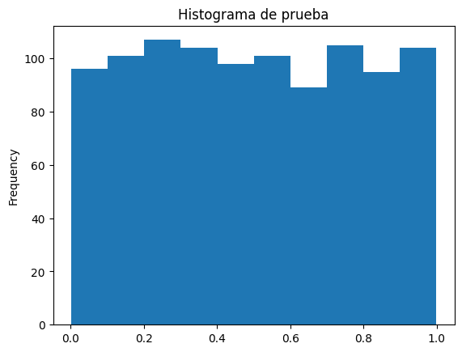

```python
prueba_histograma = pd.Series(np.random.rand(1000))

prueba_histograma.plot(kind='hist', title='Histograma de prueba')
```

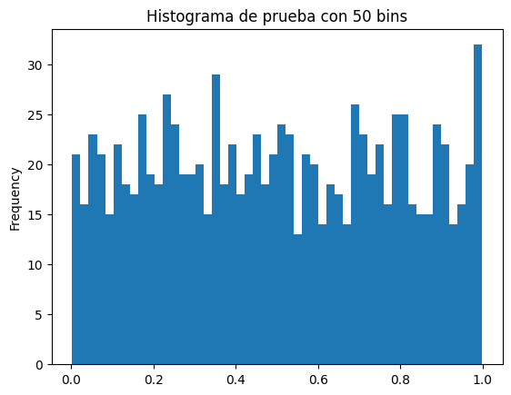

```python
prueba_histograma.plot(kind='hist', bins=50, title='Histograma de prueba con 50 bins')
```

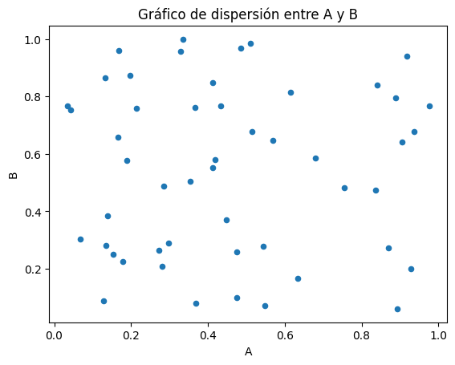

```python
df_prueba_plt = pd.DataFrame(np.random.rand(50,2), columns = ['A', 'B'])

df_prueba_plt.plot(kind='scatter', x='A', y='B', title='Gráfico de dispersión entre A y B')
```

[figure not shown]

**Dia 6** - *Aplicacion al proyecto*

Objetivo: Aplicar estas visualizaciones para empezar a extraer insights (conocimientos) de nuestro dataset de videojuegos.

Tarea:

1. Crea un histograma de la columna Year. Esto te mostrará en qué épocas se concentran la mayoría de los lanzamientos de juegos en nuestro dataset.
2. Crea un gráfico de dispersión para visualizar la relación entre las ventas de Norteamérica y Europa. Usa NA_Sales para el eje X y EU_Sales para el eje Y.
3. Interpreta los resultados: En celdas de Markdown separadas, escribe una o dos frases respondiendo a estas preguntas:

   ```
   -   Para el histograma: ¿Qué te dice el gráfico sobre la historia de los videojuegos según estos datos? ¿Hay alguna década que domine?

   -   Para el gráfico de dispersión: ¿Parece haber una correlación entre las ventas de Norteamérica y las de Europa? En otras palabras, ¿los juegos que venden bien en una región tienden a vender bien en la otra?
   ```

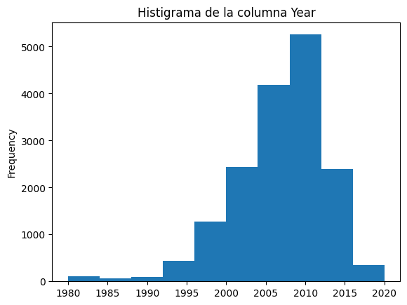

```python
df_videogames_final['Year'].plot(kind='hist', title='Histigrama de la columna Year')
```

Existio una alza de lanzamiento de video juegos entre el 2.005 y 2.010, siendo posiblemente el el moemento mas relabante en ventas.

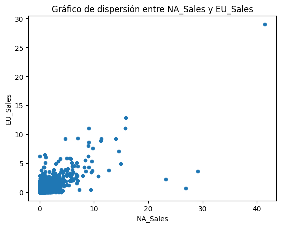

```python
df_videogames_final.plot(kind='scatter',x='NA_Sales', y='EU_Sales', title='Gráfico de dispersión entre NA_Sales y EU_Sales')
```

Se muestra una extrecha correlacion entre las ventas Norteamericanas y ventas Europeas,lo que se tiende a creer que los juegos que se venden bien en una zona, tambien lo hacen en otra.

[figure not shown]

#### Practica del Dia 7

Para el dia 7 se realizo un repaso completo desde el dia 1 al 7, por temas de claridad y orden se decidio realizar dicha practica en un nootebook aparte.

[figure not shown]

#### Practica del Dia 8

```python
df_videogames['Sales_Category'].value_counts()
```

```
Sales_Category
Venta estandar     14540
Exito de ventas     2053
Name: count, dtype: int64
```

```python
df_limpio = pd.read_csv('vgsales_limpio.csv')
```

```python
grupo_por_plataforma = df_limpio.groupby('Platform')
```

```python
grupo_por_plataforma.groups
```

```
{'2600': [89, 239, 258, 544, 607, 734, 766, 864, 1106, 1115, 1153, 1163, 1306, 1429, 1508, 1513, 1555, 1584, 1704, 1765, 1816, 1847, 1850, 1904, 1964, 1968, 2112, 2142, 2231, 2405, 2515, 2595, 2628, 2651, 2659, 2663, 2668, 2671, 2805, 2842, 2939, 3043, 3078, 3117, 3214, 3247, 3265, 3402, 3407, 3446,…
```

```python
df_ps2 = grupo_por_plataforma.get_group('PS2')

df_ps2.head()
```

|  | Rank | Name | Platform | Year | Genre | Publisher | NA_Sales | EU_Sales | JP_Sales | Other_Sales | Global_Sales | Sales_Category | Name_Lenght |
| --- | --- | --- | --- | --- | --- | --- | --- | --- | --- | --- | --- | --- | --- |
| 17 | 18 | Grand Theft Auto: San Andreas | PS2 | 2004 | Action | Take-Two Interactive | 9.43 | 0.40 | 0.41 | 10.57 | 20.81 | Exito de ventas | 29 |
| 24 | 25 | Grand Theft Auto: Vice City | PS2 | 2002 | Action | Take-Two Interactive | 8.41 | 5.49 | 0.47 | 1.78 | 16.15 | Exito de ventas | 27 |
| 28 | 29 | Gran Turismo 3: A-Spec | PS2 | 2001 | Racing | Sony Computer Entertainment | 6.85 | 5.09 | 1.87 | 1.16 | 14.98 | Exito de ventas | 22 |
| 38 | 39 | Grand Theft Auto III | PS2 | 2001 | Action | Take-Two Interactive | 6.99 | 4.51 | 0.30 | 1.30 | 13.10 | Exito de ventas | 20 |
| 47 | 48 | Gran Turismo 4 | PS2 | 2004 | Racing | Sony Computer Entertainment | 3.01 | 0.01 | 1.10 | 7.53 | 11.66 | Exito de ventas | 14 |

[figure not shown]

**Dia 8** - *Aplicacion al proyecto*

Objetivo: Aplicar el paso "Split" a nuestro proyecto y familiarizarte con la manipulación del objeto GroupBy.

Tarea:

1. Agrupa tu DataFrame vgsales_limpio por la columna Genre. Asigna el resultado a una variable llamada grupos_por_genero.
2. Inspecciona los grupos usando .groups.
3. Extrae y muestra el DataFrame completo para el género "Action" usando .get_group().
4. Desafío extra: Un objeto GroupBy se puede iterar. Intenta escribir un bucle for que recorra grupos_por_genero, e imprima para cada género su nombre y las 3 primeras filas de su DataFrame correspondiente.

```python
grupos_por_genero = df_videogames_final.groupby('Genre')

grupos_por_genero.groups
```

```
{'Action': [16, 17, 23, 24, 38, 44, 45, 51, 56, 82, 90, 94, 100, 115, 119, 123, 127, 128, 134, 138, 142, 144, 145, 146, 150, 151, 156, 159, 172, 176, 178, 185, 186, 196, 197, 198, 201, 210, 212, 216, 222, 223, 227, 229, 231, 232, 234, 236, 241, 243, 245, 262, 263, 265, 268, 273, 276, 278, 280, 284, …
```

```python
df_videogames_action = grupos_por_genero.get_group('Action')

df_videogames_action.head()
```

|  | Rank | Name | Platform | Year | Genre | Publisher | NA_Sales | EU_Sales | JP_Sales | Other_Sales | Global_Sales | Sales_Category | Name_Lenght |
| --- | --- | --- | --- | --- | --- | --- | --- | --- | --- | --- | --- | --- | --- |
| 16 | 17 | Grand Theft Auto V | PS3 | 2013 | Action | Take-Two Interactive | 7.01 | 9.27 | 0.97 | 4.14 | 21.40 | Exito de ventas | 18 |
| 17 | 18 | Grand Theft Auto: San Andreas | PS2 | 2004 | Action | Take-Two Interactive | 9.43 | 0.40 | 0.41 | 10.57 | 20.81 | Exito de ventas | 29 |
| 23 | 24 | Grand Theft Auto V | X360 | 2013 | Action | Take-Two Interactive | 9.63 | 5.31 | 0.06 | 1.38 | 16.38 | Exito de ventas | 18 |
| 24 | 25 | Grand Theft Auto: Vice City | PS2 | 2002 | Action | Take-Two Interactive | 8.41 | 5.49 | 0.47 | 1.78 | 16.15 | Exito de ventas | 27 |
| 38 | 39 | Grand Theft Auto III | PS2 | 2001 | Action | Take-Two Interactive | 6.99 | 4.51 | 0.30 | 1.30 | 13.10 | Exito de ventas | 20 |

```python
for nombre_del_genero, datos_del_genero in grupos_por_genero:
    print(f"--- Género: {nombre_del_genero} ---")
    print(datos_del_genero.head(3))
    print("\n")
```

```
--- Género: Action ---
    Rank                           Name Platform  Year   Genre  \
16    17             Grand Theft Auto V      PS3  2013  Action
17    18  Grand Theft Auto: San Andreas      PS2  2004  Action
23    24             Grand Theft Auto V     X360  2013  Action

               Publisher  NA_Sales  EU_Sales  JP_Sales  Other_Sales  \
16  Take-Two Interactive      7.01      9.27      0.97         4.14
17  Take-Two Interactive      9.43      0.40      0.41        10.57
23  Take-Two Interactive      9.63      5.31      0.06         1.38

    Global_Sales   Sales_Category  Name_Lenght
16         21.40  Exito de ventas           18
17         20.81  Exito de ventas           29
23         16.38  Exito de ventas           18


--- Género: Adventure ---
     Rank                                Name Platform  Year      Genre  \
50     51  Super Mario Land 2: 6 Golden Coins       GB  1992  Adventure
158   159                    Assassin's Creed     X360  2007  Adventure
218   219                    Assassin's Creed      PS3  2007  Adventure

    Publisher  NA_Sales  EU_Sales  JP_Sales  Other_Sales  Global_Sales  \
50   Nintendo      6.16      2.04      2.69         0.29         11.18
158   Ubisoft      3.28      1.65      0.07         0.55          5.55
218   Ubisoft      1.91      2.00      0.09         0.83          4.83

      Sales_Category  Name_Lenght
50   Exito de ventas           34
158  Exito de ventas           16
218  Exito de ventas           16


--- Género: Fighting ---
     Rank                                 Name Platform  Year     Genre  \
39     40              Super Smash Bros. Brawl      Wii  2008  Fighting
97     98  Super Smash Bros. for Wii U and 3DS      3DS  2014  Fighting
105   106                             Tekken 3       PS  1998  Fighting

```

[output cut: 147 more lines]

```
--- Género: Strategy ---
     Rank                            Name Platform  Year     Genre  \
165   166                 Pokemon Stadium      N64  1999  Strategy
204   205                    Warzone 2100       PS  1999  Strategy
217   218  StarCraft II: Wings of Liberty       PC  2010  Strategy

             Publisher  NA_Sales  EU_Sales  JP_Sales  Other_Sales  \
165           Nintendo      3.18      1.24      0.94         0.09
204  Eidos Interactive      2.79      1.89      0.00         0.33
217         Activision      2.56      1.68      0.00         0.59

     Global_Sales   Sales_Category  Name_Lenght
165          5.45  Exito de ventas           15
204          5.01  Exito de ventas           12
217          4.83  Exito de ventas           30
```

[figure not shown]

#### Practica del Dia 9

```python
df_videogames_practica9 = pd.read_csv('vgsales_limpio.csv')

df_videogames_publisher = df_videogames_practica9.groupby('Publisher')
```

```python
df_videogames_publisher.groups
```

```
{'10TACLE Studios': [12346, 14127, 15702], '1C Company': [13054, 13721, 16444], '20th Century Fox Video Games': [2595, 5387, 5393, 6726, 7146], '2D Boy': [14008], '3DO': [1543, 2429, 2545, 3459, 3577, 3662, 4456, 4623, 4931, 5111, 5174, 5507, 5832, 5897, 6614, 6787, 6870, 8227, 8290, 8371, 9066, 939…
```

```python
#Esta es una manera de hacer ver la informacion segun el minimo y max de la columna Year, con .describe()

df_videogames_publisher.get_group('Nintendo').describe()
```

|  | Rank | Year | NA_Sales | EU_Sales | JP_Sales | Other_Sales | Global_Sales | Name_Lenght |
| --- | --- | --- | --- | --- | --- | --- | --- | --- |
| count | 702.000000 | 702.000000 | 702.000000 | 702.000000 | 702.000000 | 702.000000 | 702.000000 | 702.000000 |
| mean | 3844.960114 | 2003.857550 | 1.163632 | 0.596496 | 0.648718 | 0.135798 | 2.544929 | 23.336182 |
| std | 4012.222473 | 7.748522 | 2.978580 | 1.737187 | 1.059966 | 0.462303 | 5.656354 | 13.024319 |
| min | 1.000000 | 1983.000000 | 0.000000 | 0.000000 | 0.000000 | 0.000000 | 0.010000 | 3.000000 |
| 25% | 718.500000 | 2000.000000 | 0.010000 | 0.000000 | 0.090000 | 0.000000 | 0.292500 | 14.000000 |
| 50% | 2327.500000 | 2005.000000 | 0.370000 | 0.120000 | 0.280000 | 0.030000 | 0.895000 | 20.000000 |
| 75% | 5979.750000 | 2009.000000 | 0.960000 | 0.480000 | 0.730000 | 0.090000 | 2.250000 | 29.000000 |
| max | 16545.000000 | 2016.000000 | 41.490000 | 29.020000 | 10.220000 | 8.460000 | 82.740000 | 124.000000 |

```python
#Esta es la segunda manera de hacer ver el minimo y maximo de la columna Year, pero con .min() y .max()

print(f'--- Año minimo para los juegos de Nintendo: {df_videogames_publisher.get_group('Nintendo').Year.min()} ---')
print(f'--- Año maximo para los juegos de Nintendo: {df_videogames_publisher.get_group('Nintendo').Year.max()} ---')
```

```
--- Año minimo para los juegos de Nintendo: 1983 ---
--- Año maximo para los juegos de Nintendo: 2016 ---
```

```python
grupo_por_plataforma = df_videogames_practica9.groupby('Platform')
```

```python
#Hasta .sum() es la funcion de aplicacion, despues se ordena con .sort_values() y se muestran los 10 primeros con .head(10)

grupo_por_plataforma['Global_Sales'].sum().sort_values(ascending=False).head(10)
```

```
Platform
PS2     1255.64
X360     978.67
PS3      957.35
Wii      926.69
DS       822.49
PS       730.66
GBA      318.50
PSP      296.28
PS4      278.10
PC       258.74
Name: Global_Sales, dtype: float64
```

```python
#Hasta .agg() es la funcion de aplicacion y agregacion, despues se ordena con .sort_values() y se muestran los 10 primeros con .head(10)

grupo_por_plataforma['Global_Sales'].agg(['sum', 'mean', 'max', 'min']).sort_values(by='sum', ascending=False).head(10)
```

| Platform | sum | mean | max | min |
| --- | --- | --- | --- | --- |
| PS2 | 1255.64 | 0.581046 | 20.81 | 0.01 |
| X360 | 978.67 | 0.774264 | 21.82 | 0.01 |
| PS3 | 957.35 | 0.721439 | 21.40 | 0.01 |
| Wii | 926.69 | 0.699917 | 82.74 | 0.01 |
| DS | 822.49 | 0.380254 | 30.01 | 0.01 |
| PS | 730.66 | 0.610920 | 10.95 | 0.01 |
| GBA | 318.50 | 0.387470 | 15.85 | 0.01 |
| PSP | 296.28 | 0.244254 | 7.72 | 0.01 |
| PS4 | 278.10 | 0.827679 | 14.24 | 0.01 |
| PC | 258.74 | 0.269802 | 8.11 | 0.01 |

```python
grupo_por_plataforma.agg({
    'NA_Sales': 'sum',
    'EU_Sales': 'mean'
                        }).sort_values(by='NA_Sales', ascending=False).head(10)
```

| Platform | NA_Sales | EU_Sales |
| --- | --- | --- |
| X360 | 600.05 | 0.221843 |
| PS2 | 583.84 | 0.157006 |
| Wii | 507.71 | 0.202704 |
| PS3 | 392.26 | 0.258644 |
| DS | 390.71 | 0.089991 |
| PS | 336.51 | 0.178595 |
| GBA | 187.54 | 0.091545 |
| XB | 186.69 | 0.073968 |
| N64 | 139.02 | 0.128715 |
| GC | 133.46 | 0.069622 |

[figure not shown]

**Dia 9** - *Aplicacion al proyecto*

Objetivo: Usar las agregaciones para responder preguntas de negocio reales sobre nuestro dataset.

Tarea: Responde a las siguientes preguntas en celdas separadas.

1. ¿Cuál es el total de Global_Sales por cada Publisher? Ordena el resultado de mayor a menor para que puedas ver fácilmente el Top 5 de los editores más exitosos.
2. ¿Cuál es la venta promedio en Norteamérica (NA_Sales) para cada Genre? ¿Qué género de juego vende más en promedio en esa región?
3. Usando .agg() en una sola operación, calcula para cada Platform:
   - La venta media en Japón (JP_Sales).
   - La venta máxima en Europa (EU_Sales).

```python
grupo_por_publisher = df_videogames_limpio.groupby('Publisher')

print(f'Agrupacion por: {grupo_por_publisher['Global_Sales'].sum().sort_values(ascending=False).head(5)}')
```

```
Agrupacion por: Publisher
Nintendo                       1784.43
Electronic Arts                1093.39
Activision                      721.41
Sony Computer Entertainment     607.28
Ubisoft                         473.54
Name: Global_Sales, dtype: float64
```

```python
grupo_por_genre = df_videogames_limpio.groupby('Genre')

print(f'Agrupacion por: {grupo_por_genre['NA_Sales'].mean().sort_values(ascending=False).head(3)}')
```

```
Agrupacion por: Genre
Platform    0.509703
Shooter     0.448643
Racing      0.291371
Name: NA_Sales, dtype: float64
```

```python
grupo_por_plataforma = df_videogames_limpio.groupby('Platform')

print(f'{grupo_por_plataforma.agg({
    'JP_Sales': 'mean',
    'EU_Sales': 'max'})}')
```

```
          JP_Sales  EU_Sales
Platform
2600      0.000000      0.45
3DO       0.033333      0.00
3DS       0.194990      4.05
DC        0.164615      0.61
DS        0.082130     11.00
GB        0.877526      8.89
GBA       0.059237      3.90
GC        0.039373      1.77
GEN       0.098889      1.20
GG        0.040000      0.00
N64       0.106835      2.85
NES       1.006633      3.58
NG        0.120000      0.00
PC        0.000181      6.42
PCFX      0.030000      0.00
PS        0.117561      3.87
PS2       0.064664      5.49
PS3       0.060744      9.27
PS4       0.042560      6.06
PSP       0.063400      2.83
PSV       0.050878      0.79
SAT       0.186474      0.26
SCD       0.075000      0.36
SNES      0.487657      3.75
TG16      0.080000      0.00
WS        0.236667      0.00
Wii       0.052930     29.02
WiiU      0.089441      2.07
X360      0.009968      5.31
XB        0.001719      1.53
XOne      0.001596      2.11
```

[figure not shown]

#### Practica del Dia 10

```python
grupos_por_genre = df_videogames_limpio.groupby('Genre')

print(f'----Cantidad de juegos por genero----\n {grupos_por_genre.size().sort_values(ascending=False)}')
```

```
----Cantidad de juegos por genero----
 Genre
Action          3251
Sports          2304
Misc            1686
Role-Playing    1470
Shooter         1282
Adventure       1274
Racing          1225
Platform         875
Simulation       848
Fighting         836
Strategy         670
Puzzle           570
dtype: int64
```

```python
#En este punto estoy entendiendo la logica de .merge() que es como un JOIN de SQL y como se puede usar para unir DataFrames. donde 'how' puede ser 'inner', 'outer', 'left' o 'right' dependiendo de como se quiera hacer la union.

df1 = pd.DataFrame({'empleado': ['Ana', 'Luis', 'Carlos', 'Antonio'],
                    'grupo': ['Contabilidad', 'Ventas', 'Marketing', 'IT']})
df2 = pd.DataFrame({'empleado': ['Ana', 'Luis', 'Carlos', 'Antonio'],
                    'fecha_de_contratacion': [2012, 2014, 2015, 2016]})

print('---- INNER JOIN ----')
print(pd.merge(df1, df2, on = 'empleado', how = 'inner')) #usamos on para indicar la columna comun entre ambos DataFrames, algo asi como en SQL la primery key y foreign key.
```

```
---- INNER JOIN ----
  empleado         grupo  fecha_de_contratacion
0      Ana  Contabilidad                   2012
1     Luis        Ventas                   2014
2   Carlos     Marketing                   2015
3  Antonio            IT                   2016
```

```python
df3 = pd.DataFrame({'empleado': ['Ana', 'Luis', 'Carlos', 'Antonio', 'Parodi'],
                    'grupo': ['Contabilidad', 'Ventas', 'Marketing', 'IT', 'Chofer']})

print('---- LEFT JOIN ----')
print(pd.merge(df3, df2, on = 'empleado', how = 'left'))
```

```
---- LEFT JOIN ----
  empleado         grupo  fecha_de_contratacion
0      Ana  Contabilidad                 2012.0
1     Luis        Ventas                 2014.0
2   Carlos     Marketing                 2015.0
3  Antonio            IT                 2016.0
4   Parodi        Chofer                    NaN
```

[figure not shown]

**Dia 10** - *Aplicacion al proyecto*

Objetivo: Enriquecer nuestro dataset de videojuegos con información externa.

Tarea:

Crea un DataFrame de Información Externa: Vamos a crear una pequeña tabla con el país de origen de algunos de los principales publishers. Copia y pega este código en una celda:

```
Python

df_publishers = pd.DataFrame({
        'Publisher': ['Nintendo', 'Activision', 'Sony Computer Entertainment', 'Electronic Arts', 'Ubisoft'],
        'Country': ['Japan', 'USA', 'Japan', 'USA', 'France']
                            })
```

1. Une los DataFrames: Tu misión es usar pd.merge() para añadir la columna Country de df_publishers a tu DataFrame principal vgsales_limpio.
2. Pregunta de Analista: ¿Qué valor para el parámetro how deberías usar si quieres asegurarte de no perder ningún juego de tu lista original en el proceso, incluso si su Publisher no está en nuestra nueva tabla df_publishers?
3. Ejecuta el merge, guarda el resultado en un nuevo DataFrame llamado df_con_pais y muéstralo con .head(). Comprueba cómo los juegos de Nintendo ahora tienen "Japan" en la columna Country.

```python
df_plublisher = pd.DataFrame({
                        'Publisher': ['Nintendo', 'Activision', 'Sony Computer Entertainment', 'Electronic Arts', 'Ubisoft'],
                        'Country': ['Japan', 'USA', 'Japan', 'USA', 'France']
                            })

df_con_pais = pd.merge(df_videogames_limpio, df_plublisher, on = 'Publisher', how = 'left')

df_con_pais
```

|  | Rank | Name | Platform | Year | Genre | Publisher | NA_Sales | EU_Sales | JP_Sales | Other_Sales | Global_Sales | Country |
| --- | --- | --- | --- | --- | --- | --- | --- | --- | --- | --- | --- | --- |
| 0 | 1 | Wii Sports | Wii | 2006.0 | Sports | Nintendo | 41.49 | 29.02 | 3.77 | 8.46 | 82.74 | Japan |
| 1 | 2 | Super Mario Bros. | NES | 1985.0 | Platform | Nintendo | 29.08 | 3.58 | 6.81 | 0.77 | 40.24 | Japan |
| 2 | 3 | Mario Kart Wii | Wii | 2008.0 | Racing | Nintendo | 15.85 | 12.88 | 3.79 | 3.31 | 35.82 | Japan |
| 3 | 4 | Wii Sports Resort | Wii | 2009.0 | Sports | Nintendo | 15.75 | 11.01 | 3.28 | 2.96 | 33.00 | Japan |
| 4 | 5 | Pokemon Red/Pokemon Blue | GB | 1996.0 | Role-Playing | Nintendo | 11.27 | 8.89 | 10.22 | 1.00 | 31.37 | Japan |
| ... | ... | ... | ... | ... | ... | ... | ... | ... | ... | ... | ... | ... |
| 16286 | 16596 | Woody Woodpecker in Crazy Castle 5 | GBA | 2002.0 | Platform | Kemco | 0.01 | 0.00 | 0.00 | 0.00 | 0.01 | NaN |
| 16287 | 16597 | Men in Black II: Alien Escape | GC | 2003.0 | Shooter | Infogrames | 0.01 | 0.00 | 0.00 | 0.00 | 0.01 | NaN |
| 16288 | 16598 | SCORE International Baja 1000: The Official Game | PS2 | 2008.0 | Racing | Activision | 0.00 | 0.00 | 0.00 | 0.00 | 0.01 | USA |
| 16289 | 16599 | Know How 2 | DS | 2010.0 | Puzzle | 7G//AMES | 0.00 | 0.01 | 0.00 | 0.00 | 0.01 | NaN |
| 16290 | 16600 | Spirits & Spells | GBA | 2003.0 | Platform | Wanadoo | 0.01 | 0.00 | 0.00 | 0.00 | 0.01 | NaN |

16291 rows × 12 columns

```python
df_con_pais_nintendo = df_con_pais[df_con_pais['Publisher'] == 'Nintendo']

df_con_pais_nintendo.head()
```

|  | Rank | Name | Platform | Year | Genre | Publisher | NA_Sales | EU_Sales | JP_Sales | Other_Sales | Global_Sales | Country |
| --- | --- | --- | --- | --- | --- | --- | --- | --- | --- | --- | --- | --- |
| 0 | 1 | Wii Sports | Wii | 2006.0 | Sports | Nintendo | 41.49 | 29.02 | 3.77 | 8.46 | 82.74 | Japan |
| 1 | 2 | Super Mario Bros. | NES | 1985.0 | Platform | Nintendo | 29.08 | 3.58 | 6.81 | 0.77 | 40.24 | Japan |
| 2 | 3 | Mario Kart Wii | Wii | 2008.0 | Racing | Nintendo | 15.85 | 12.88 | 3.79 | 3.31 | 35.82 | Japan |
| 3 | 4 | Wii Sports Resort | Wii | 2009.0 | Sports | Nintendo | 15.75 | 11.01 | 3.28 | 2.96 | 33.00 | Japan |
| 4 | 5 | Pokemon Red/Pokemon Blue | GB | 1996.0 | Role-Playing | Nintendo | 11.27 | 8.89 | 10.22 | 1.00 | 31.37 | Japan |

[figure not shown]

#### Practica del Dia 11

```python
#Segun mi forma de entender la pregunta, creo que existen verias formas de de responder esta incongnita empresarial y
#todo creo tambien que el resultado dependera de si se necesitan los valores unicos de los nombres, por ejemplo: el juego call of duty: Black ops
#podria repetirse en varias compañias. Dejando esto de lado podria decir que el valo bruto de los juegos lo podriamos determinas de la siguiente manera


#La Primera

df_con_pais_usa = df_con_pais[df_con_pais['Country'] == 'USA']

print(f' La la cantidad de juegos del pais USA es: {df_con_pais_usa['Country'].count()}')
```

```
 La la cantidad de juegos del pais USA es: 2305
```

```python
#La Segunda

#Al DataFrame que creamos antiguamente usamos .info para saber el recuento de la columna name
df_con_pais_usa.info()
```

```
<class 'pandas.core.frame.DataFrame'>
Index: 2305 entries, 29 to 16288
Data columns (total 12 columns):
 #   Column        Non-Null Count  Dtype
---  ------        --------------  -----
 0   Rank          2305 non-null   int64
 1   Name          2305 non-null   object
 2   Platform      2305 non-null   object
 3   Year          2305 non-null   float64
 4   Genre         2305 non-null   object
 5   Publisher     2305 non-null   object
 6   NA_Sales      2305 non-null   float64
 7   EU_Sales      2305 non-null   float64
 8   JP_Sales      2305 non-null   float64
 9   Other_Sales   2305 non-null   float64
 10  Global_Sales  2305 non-null   float64
 11  Country       2305 non-null   object
dtypes: float64(6), int64(1), object(5)
memory usage: 234.1+ KB
```

```python
#La Tercera

grupo_por_paises = df_con_pais.groupby('Country')

print(f'Cantidades por paises: \n {grupo_por_paises.size().sort_values(ascending=False)}')
```

```
Cantidades por paises:
 Country
USA       2305
Japan     1378
France     918
dtype: int64
```

```python
df_para_sns = pd.read_csv('vgsales_limpio.csv')
```

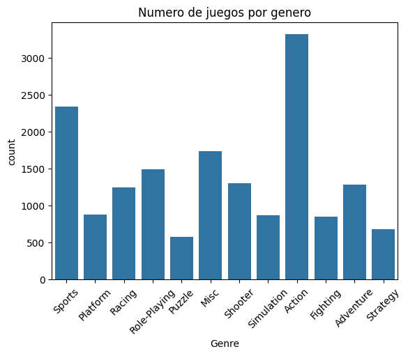

```python
plt.Figure(figsize=(10, 6))
sns.countplot(x = 'Genre', data=df_para_sns)
plt.title('Numero de juegos por genero')
plt.xticks(rotation=45)
plt.show()
```

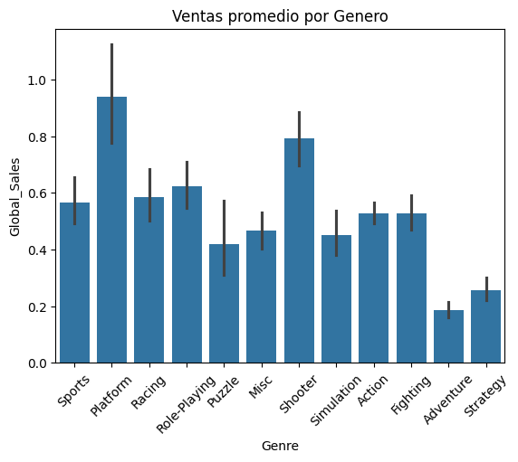

```python
plt.Figure(figsize=(10, 6))
sns.barplot(x = 'Genre', y = 'Global_Sales', data=df_para_sns)
plt.title('Ventas promedio por Genero')
plt.xticks(rotation= 45)
plt.show()
```

[figure not shown]

**Dia 11** - *Aplicacion al proyecto*

Objetivo: Usar Seaborn para crear visualizaciones que respondan a preguntas de negocio a partir de los resultados de un .groupby().

Tarea:

Análisis de Ventas por Género (barplot):

1. Primero, calcula las ventas totales (Global_Sales) para cada Genre. Guarda este resultado (que será una Serie) en una nueva variable.
   - Usa seaborn.barplot() para visualizar este resultado. Pon los géneros en el eje X y las ventas totales en el eje Y.
   - No olvides ordenar el gráfico de mayor a menor para que el resultado sea fácil de interpretar.
2. Análisis de Cantidad por Plataforma (countplot):
   - Usa seaborn.countplot() para visualizar el número de juegos que hay por cada Platform.
   - Desafío: El gráfico tendrá demasiadas plataformas. Investiga cómo usar el método .value_counts() y .head(15) para quedarte solo con las 15 plataformas con más juegos antes de pasárselas a Seaborn.
3. Interpretación: En una celda de Markdown, escribe una breve conclusión para cada uno de los dos gráficos que creaste. ¿Qué te dicen?

```python
grupos_por_generos = df_con_pais.groupby('Genre')

ventas_globales_por_genero = grupos_por_generos['Global_Sales'].sum().sort_values(ascending=False)

ventas_globales_por_genero
```

```
Genre
Action          1722.84
Sports          1309.24
Shooter         1026.20
Role-Playing     923.83
Platform         829.13
Misc             789.87
Racing           726.76
Fighting         444.05
Simulation       389.98
Puzzle           242.21
Adventure        234.59
Strategy         173.27
Name: Global_Sales, dtype: float64
```

```python
df_ventas_globales_por_genero = pd.DataFrame(data=ventas_globales_por_genero)

df_ventas_globales_por_genero
```

| Genre | Global_Sales |
| --- | --- |
| Action | 1722.84 |
| Sports | 1309.24 |
| Shooter | 1026.20 |
| Role-Playing | 923.83 |
| Platform | 829.13 |
| Misc | 789.87 |
| Racing | 726.76 |
| Fighting | 444.05 |
| Simulation | 389.98 |
| Puzzle | 242.21 |
| Adventure | 234.59 |
| Strategy | 173.27 |

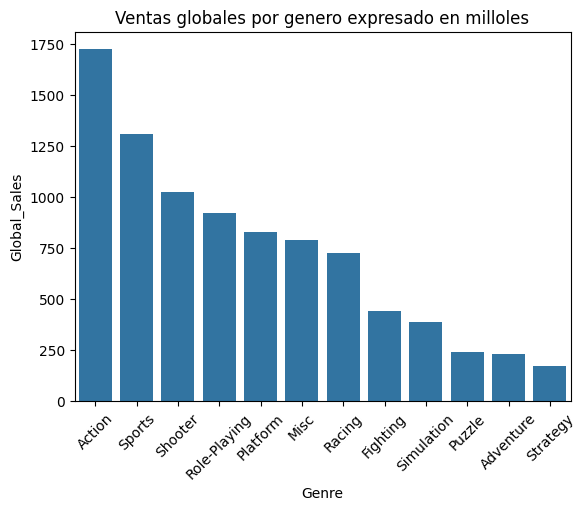

```python
plt.Figure(figsize=(15,10))
sns.barplot(x='Genre', y='Global_Sales', data=df_ventas_globales_por_genero)
plt.title('Ventas globales por genero expresado en milloles')
plt.xticks(rotation=45)
plt.show()
```

Se puede observar en el grafico que para las ventas globales lidera el genero 'Action' como el mas vendido.

```python
top_15_plataformas = df_con_pais['Platform'].value_counts().sort_values(ascending=False).head(15).index

top_15_plataformas
```

```
Index(['DS', 'PS2', 'PS3', 'Wii', 'X360', 'PSP', 'PS', 'PC', 'XB', 'GBA', 'GC',
       '3DS', 'PSV', 'PS4', 'N64'],
      dtype='object', name='Platform')
```

```python
df_top_15_plataformas = df_con_pais[df_con_pais['Platform'].isin(top_15_plataformas)]

df_top_15_plataformas
```

|  | Rank | Name | Platform | Year | Genre | Publisher | NA_Sales | EU_Sales | JP_Sales | Other_Sales | Global_Sales | Country |
| --- | --- | --- | --- | --- | --- | --- | --- | --- | --- | --- | --- | --- |
| 0 | 1 | Wii Sports | Wii | 2006.0 | Sports | Nintendo | 41.49 | 29.02 | 3.77 | 8.46 | 82.74 | Japan |
| 2 | 3 | Mario Kart Wii | Wii | 2008.0 | Racing | Nintendo | 15.85 | 12.88 | 3.79 | 3.31 | 35.82 | Japan |
| 3 | 4 | Wii Sports Resort | Wii | 2009.0 | Sports | Nintendo | 15.75 | 11.01 | 3.28 | 2.96 | 33.00 | Japan |
| 6 | 7 | New Super Mario Bros. | DS | 2006.0 | Platform | Nintendo | 11.38 | 9.23 | 6.50 | 2.90 | 30.01 | Japan |
| 7 | 8 | Wii Play | Wii | 2006.0 | Misc | Nintendo | 14.03 | 9.20 | 2.93 | 2.85 | 29.02 | Japan |
| ... | ... | ... | ... | ... | ... | ... | ... | ... | ... | ... | ... | ... |
| 16286 | 16596 | Woody Woodpecker in Crazy Castle 5 | GBA | 2002.0 | Platform | Kemco | 0.01 | 0.00 | 0.00 | 0.00 | 0.01 | NaN |
| 16287 | 16597 | Men in Black II: Alien Escape | GC | 2003.0 | Shooter | Infogrames | 0.01 | 0.00 | 0.00 | 0.00 | 0.01 | NaN |
| 16288 | 16598 | SCORE International Baja 1000: The Official Game | PS2 | 2008.0 | Racing | Activision | 0.00 | 0.00 | 0.00 | 0.00 | 0.01 | USA |
| 16289 | 16599 | Know How 2 | DS | 2010.0 | Puzzle | 7G//AMES | 0.00 | 0.01 | 0.00 | 0.00 | 0.01 | NaN |
| 16290 | 16600 | Spirits & Spells | GBA | 2003.0 | Platform | Wanadoo | 0.01 | 0.00 | 0.00 | 0.00 | 0.01 | NaN |

15102 rows × 12 columns

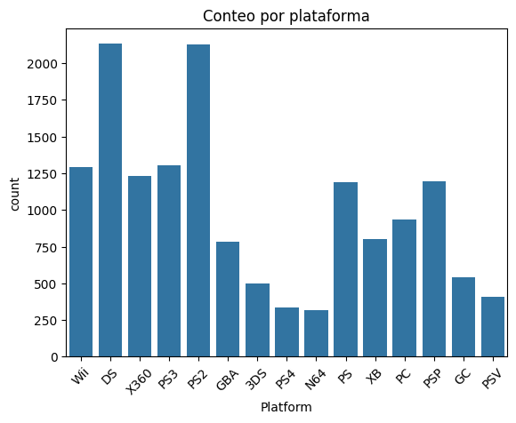

```python
plt.Figure(figsize=(15, 10))
sns.countplot(x='Platform', data=df_top_15_plataformas)
plt.title('Conteo por plataforma')
plt.xticks(rotation=45)
plt.show()
```

Segun nuestra grafica, este nos muestra que existen 2 plataformas que lideran el numero de juegos superando los 2,000 en cada una de ellas.

[figure not shown]

```python
grupos_por_platform = df_videogames_limpio.groupby('Platform')

df_por_platform = grupo_por_plataforma['Global_Sales'].sum().sort_values(ascending=False).head(10)

df_por_platform_para_graficar = pd.DataFrame(df_por_platform)

df_por_platform_para_graficar
```

| Platform | Global_Sales |
| --- | --- |
| PS2 | 1233.46 |
| X360 | 969.60 |
| PS3 | 949.35 |
| Wii | 909.81 |
| DS | 818.91 |
| PS | 727.39 |
| GBA | 305.62 |
| PSP | 291.71 |
| PS4 | 278.10 |
| PC | 254.70 |

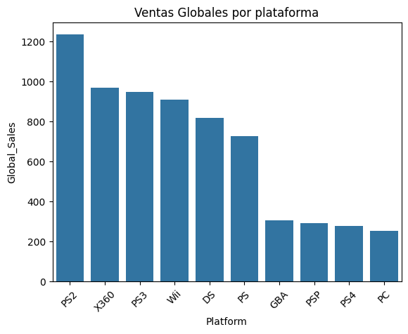

```python
plt.Figure(figsize=(15,10))
sns.barplot(x='Platform', y='Global_Sales', data=df_por_platform_para_graficar)
plt.title('Ventas Globales por plataforma')
plt.xticks(rotation=45)
plt.show()
```

[figure not shown]

**Dia 12** - *Aplicacion al proyecto*

Objetivo: Usar todas las habilidades que has aprendido esta semana para responder a una pregunta de negocio ambigua, como las que te encontrarás en un trabajo real o en una entrevista técnica. No hay una única respuesta correcta; lo que se evalúa es tu proceso de pensamiento, tu ejecución y cómo justificas tu recomendación.

El Escenario: Imagina que trabajas como analista de datos para una empresa de desarrollo de videojuegos. Tu jefe te llama y te dice:

```
    "Antonio, estamos pensando en desarrollar un nuevo juego de Acción. Basado en los datos históricos de ventas, necesito tu recomendación en dos puntos clave:
```

1. Plataforma: ¿En qué plataforma o plataformas deberíamos enfocar nuestro lanzamiento para maximizar las ventas globales?
2. Marketing Regional: ¿En qué región del mundo (Norteamérica, Europa o Japón) deberíamos invertir más en marketing para este nuevo juego de Acción?"

Tu Tarea: Tienes el resto de la sesión para explorar los datos, usar groupby, filtrar y crear las visualizaciones que necesites para construir una recomendación sólida.

No te limites a un solo número. Por ejemplo, para la plataforma, no basta con ver cuál ha vendido más históricamente. Considera la relevancia actual de las plataformas (¿siguen activas consolas como la PS2?).

Justifica cada paso. Usa celdas de Markdown para explicar tu razonamiento.

Presenta una conclusión clara. Al final, escribe un resumen con tu recomendación final para tu jefe.

```python
grupos_por_genre = df_videogames_limpio.groupby('Genre')

genero_action = grupos_por_genre.get_group('Action')

genero_action
```

|  | Rank | Name | Platform | Year | Genre | Publisher | NA_Sales | EU_Sales | JP_Sales | Other_Sales | Global_Sales |
| --- | --- | --- | --- | --- | --- | --- | --- | --- | --- | --- | --- |
| 16 | 17 | Grand Theft Auto V | PS3 | 2013.0 | Action | Take-Two Interactive | 7.01 | 9.27 | 0.97 | 4.14 | 21.40 |
| 17 | 18 | Grand Theft Auto: San Andreas | PS2 | 2004.0 | Action | Take-Two Interactive | 9.43 | 0.40 | 0.41 | 10.57 | 20.81 |
| 23 | 24 | Grand Theft Auto V | X360 | 2013.0 | Action | Take-Two Interactive | 9.63 | 5.31 | 0.06 | 1.38 | 16.38 |
| 24 | 25 | Grand Theft Auto: Vice City | PS2 | 2002.0 | Action | Take-Two Interactive | 8.41 | 5.49 | 0.47 | 1.78 | 16.15 |
| 38 | 39 | Grand Theft Auto III | PS2 | 2001.0 | Action | Take-Two Interactive | 6.99 | 4.51 | 0.30 | 1.30 | 13.10 |
| ... | ... | ... | ... | ... | ... | ... | ... | ... | ... | ... | ... |
| 16564 | 16567 | Original Frisbee Disc Sports: Ultimate & Golf | DS | 2007.0 | Action | Destination Software, Inc | 0.01 | 0.00 | 0.00 | 0.00 | 0.01 |
| 16567 | 16570 | Fujiko F. Fujio Characters: Great Assembly! Sl... | 3DS | 2014.0 | Action | Namco Bandai Games | 0.00 | 0.00 | 0.01 | 0.00 | 0.01 |
| 16582 | 16585 | Planet Monsters | GBA | 2001.0 | Action | Titus | 0.01 | 0.00 | 0.00 | 0.00 | 0.01 |
| 16583 | 16586 | Carmageddon 64 | N64 | 1999.0 | Action | Virgin Interactive | 0.01 | 0.00 | 0.00 | 0.00 | 0.01 |
| 16589 | 16592 | Chou Ezaru wa Akai Hana: Koi wa Tsuki ni Shiru... | PSV | 2016.0 | Action | dramatic create | 0.00 | 0.00 | 0.01 | 0.00 | 0.01 |

3251 rows × 11 columns

```python
grupos_por_plataformas_de_action = genero_action.groupby('Platform')

top_10_plataformas = grupos_por_plataformas_de_action['Global_Sales'].sum().sort_values(ascending=False).head(10)

top_10_plataformas
```

```
Platform
PS3     304.02
PS2     272.43
X360    239.67
PS      125.74
DS      114.16
Wii     110.48
PS4      87.06
PSP      62.66
3DS      56.61
GBA      54.26
Name: Global_Sales, dtype: float64
```

```python
df_top_10_plataformas_de_action = pd.DataFrame(top_10_plataformas)

df_top_10_plataformas_de_action
```

| Platform | Global_Sales |
| --- | --- |
| PS3 | 304.02 |
| PS2 | 272.43 |
| X360 | 239.67 |
| PS | 125.74 |
| DS | 114.16 |
| Wii | 110.48 |
| PS4 | 87.06 |
| PSP | 62.66 |
| 3DS | 56.61 |
| GBA | 54.26 |

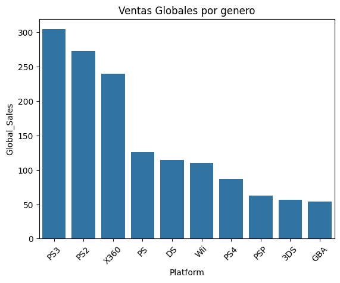

```python
plt.Figure(figsize=(15, 10))
sns.barplot(x='Platform', y='Global_Sales', data=df_top_10_plataformas_de_action)
plt.title('Ventas Globales por genero')
plt.xticks(rotation=45)
plt.show()
```

Considerando la base actual se puede determinar que:

Hoy, año 2025 para maximizar las ventas globales, a simple vista parace ser considerar las 3 primera plataformas (PS3, PS2 y X360) pero he de señalar que dicha grafica, existen varias plataformas que en la actualidad ya se encientran fuera del mercado y que en la actualidad solo se encuentran vigentes las PS3 que casi esta fuera del mercado y PS4. por lo que mi recomendacion para la compañia seria enfocar nuestros lanzamientos en la plataforma PS4 para maximixar las ventas globales.

```python
ventas_por_pais = genero_action.agg({
    'NA_Sales': 'sum',
    'EU_Sales': 'sum',
    'JP_Sales': 'sum'
})

df_ventas_por_region = ventas_por_pais.reset_index()

df_ventas_por_region.columns = ['Region', 'Total_Sales']

df_ventas_por_region
```

|  | Region | Total_Sales |
| --- | --- | --- |
| 0 | NA_Sales | 861.77 |
| 1 | EU_Sales | 516.48 |
| 2 | JP_Sales | 158.65 |

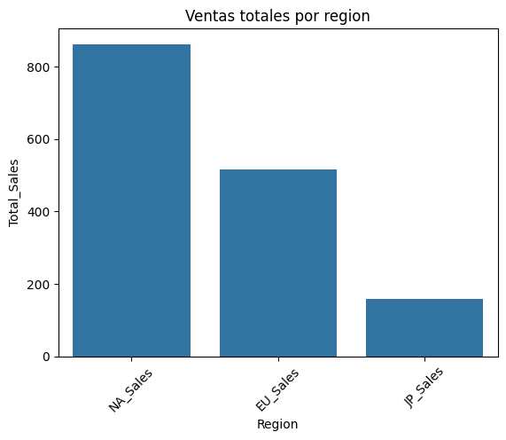

```python
plt.Figure(figsize=(15,10))
sns.barplot(x='Region', y='Total_Sales', data=df_ventas_por_region)
plt.title('Ventas totales por region')
plt.xticks(rotation=45)
plt.show()
```